# Generalized Additive Models and Spline Models

2023-10-01T17:26:23-05:00

In statistics, a generalized additive model (GAM) is a generalized linear model in which the linear response variable depends linearly on unknown smooth functions of some predictor variables, and interest focuses on inference about these smooth functions.

GAMs were originally developed to blend properties of generalized linear models with additive models.The model relates a univariate response variable, Y, to some predictor variables, x$i$. An exponential family distribution is specified for Y (for example normal, binomial or Poisson distributions) along with a link function g (for example the identity or log functions) relating the expected value of Y to the predictor variables.

More on this from wiki article: https://en.wikipedia.org/wiki/Generalized_additive_model

Here, we will use the body fat data ($\textbf{ bodyfat}$ data from $\textbf{TH.data}$ package) for some analysis. First, we will explore the data graphically to see what variables need to be included for predicting `bodyfat`, i.e., we can check for the correlated predictors.

```r
library(ggplot2)
library(mgcv)
library(mboost)
library(caret)
library(gamclass)
library (TH.data)
data ("bodyfat")
head(bodyfat)
```

```
##    age DEXfat waistcirc hipcirc elbowbreadth kneebreadth anthro3a anthro3b
## 47  57  41.68     100.0   112.0          7.1         9.4     4.42     4.95
## 48  65  43.29      99.5   116.5          6.5         8.9     4.63     5.01
## 49  59  35.41      96.0   108.5          6.2         8.9     4.12     4.74
## 50  58  22.79      72.0    96.5          6.1         9.2     4.03     4.48
## 51  60  36.42      89.5   100.5          7.1        10.0     4.24     4.68
## 52  61  24.13      83.5    97.0          6.5         8.8     3.55     4.06
##    anthro3c anthro4
## 47     4.50    6.13
## 48     4.48    6.37
## 49     4.60    5.82
## 50     3.91    5.66
## 51     4.15    5.91
## 52     3.64    5.14
```

```r
NROW(bodyfat)
```

```
## [1] 71
```

```r
library(DescTools)
names(bodyfat)
```

```
##  [1] "age"          "DEXfat"       "waistcirc"    "hipcirc"      "elbowbreadth"
##  [6] "kneebreadth"  "anthro3a"     "anthro3b"     "anthro3c"     "anthro4"
```

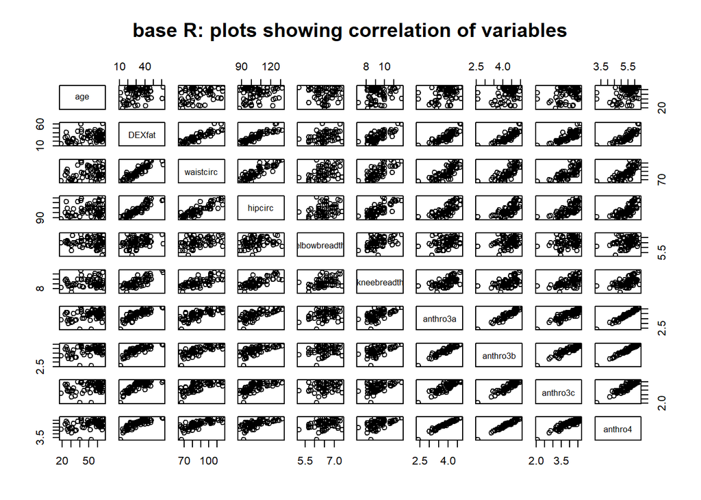

```r
library(ggplot2)
library(GGally)
library(knitr)

# plot the variables to see which variables are correlated
# base plot
pairs(bodyfat, main = "base R: plots showing correlation of variables")
```

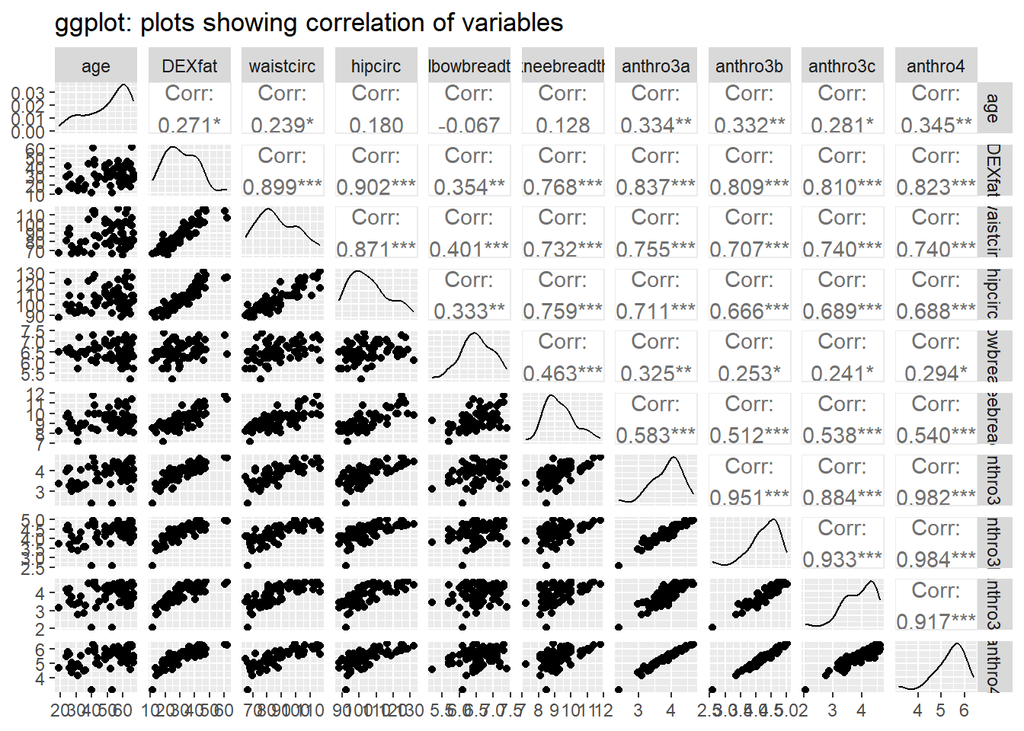

```r
#ggplot
p <- ggpairs(bodyfat)
p + labs(title = "ggplot: plots showing correlation of variables")
```

```r
cat("all of the anthros correlate with each other")
```

```
## all of the anthros correlate with each other
```

```r
body_f <- glm(DEXfat ~ ., data=bodyfat)
bf_step <- step(body_f, trace = 0)

cat("step recommends: waistcirc, hipcirc, kneebreadth and anthro3b")
```

```
## step recommends: waistcirc, hipcirc, kneebreadth and anthro3b
```

```r
bf_step
```

```
##
## Call:  glm(formula = DEXfat ~ waistcirc + hipcirc + kneebreadth + anthro3b,
##     data = bodyfat)
##
## Coefficients:
## (Intercept)    waistcirc      hipcirc  kneebreadth     anthro3b
##    -71.7197       0.2037       0.3546       1.8047       7.1264
##
## Degrees of Freedom: 70 Total (i.e. Null);  66 Residual
## Null Deviance:       8536
## Residual Deviance: 676.9     AIC: 373.6
```

```r
kable(summary(bf_step)$coefficients, caption = "Coefficients from step function")
```

Coefficients from step function

|  | Estimate | Std. Error | t value | Pr(>\|t\|) |
| --- | --- | --- | --- | --- |
| (Intercept) | -71.7196776 | 5.0140437 | -14.303760 | 0.0000000 |
| waistcirc | 0.2037314 | 0.0609069 | 3.344966 | 0.0013605 |
| hipcirc | 0.3546222 | 0.0767978 | 4.617607 | 0.0000185 |
| kneebreadth | 1.8047490 | 0.6611504 | 2.729710 | 0.0081187 |
| anthro3b | 7.1264238 | 1.1295927 | 6.308844 | 0.0000000 |

From the plot, it appears that the variables age and elbowbreadth don’t correlate with DEXfat. However, waistcirc, hipcirc, and all four anthro variables appear to correlate with DEXfat. In this case, I would select waistcirc, hipcirc, anthro3a and anthro3c. I would also test the model using anthro3b rather than anthro3a to see which yields a better model. Additionally, stepwise regression using `step()` function recommended the following variables for selection: kneebreadth, waistcirc, hipcirc and anthro3b. This suggests that anthro variables are sufficiently correlated, and could be represented by one variable which in this case is anthro3b.

Now, we will fit a generalized additive model assuming normal errors.

```
bodyfat_gam <- gam(DEXfat~ s(age) + s(waistcirc) + s(hipcirc) +
              s(elbowbreadth) + s(kneebreadth)+ s(anthro3a) +
              s(anthro3c), data = bodyfat)
```

Then assess the $\textbf{summary()}$ and $\textbf{plot()}$ of the model to see if any covariates are informative. We will check if all the covariates need to be smoothed or included as a linear effect. We will report on GCV, AIC, adj-R$^2$, and the total model degrees of freedom. We will use $\textbf{gam.check()}$ function to look at the diagnostic plot to see if the normality assumption is violated.

```r
bodyfat_gam <- gam(DEXfat ~ s(age) + s(waistcirc) + s(hipcirc) +
                     s(elbowbreadth) + s(kneebreadth) + s(anthro3a) + s(anthro3c),
                   data = bodyfat)

# Assess Summary
summary(bodyfat_gam)
```

```
##
## Family: gaussian
## Link function: identity
##
## Formula:
## DEXfat ~ s(age) + s(waistcirc) + s(hipcirc) + s(elbowbreadth) +
##     s(kneebreadth) + s(anthro3a) + s(anthro3c)
##
## Parametric coefficients:
##             Estimate Std. Error t value Pr(>|t|)
## (Intercept)  30.7828     0.2847   108.1   <2e-16 ***
## ---
## Signif. codes:  0 '***' 0.001 '**' 0.01 '*' 0.05 '.' 0.1 ' ' 1
##
## Approximate significance of smooth terms:
##                   edf Ref.df      F  p-value
## s(age)          1.000  1.000  0.956 0.333043
## s(waistcirc)    1.000  1.000 10.821 0.001885 **
## s(hipcirc)      1.775  2.235  9.917 0.000171 ***
## s(elbowbreadth) 1.000  1.000  0.001 0.972248
## s(kneebreadth)  8.754  8.960  6.180 8.35e-06 ***
## s(anthro3a)     1.000  1.000 12.966 0.000751 ***
## s(anthro3c)     7.042  8.041  1.798 0.100906
## ---
## Signif. codes:  0 '***' 0.001 '**' 0.01 '*' 0.05 '.' 0.1 ' ' 1
##
## R-sq.(adj) =  0.953   Deviance explained = 96.7%
## GCV = 8.4354  Scale est. = 5.7538    n = 71
```

```r
# Assess plot
cat ("Plot of a generalized additive model for question 1b:")
```

```
## Plot of a generalized additive model for question 1b:
```

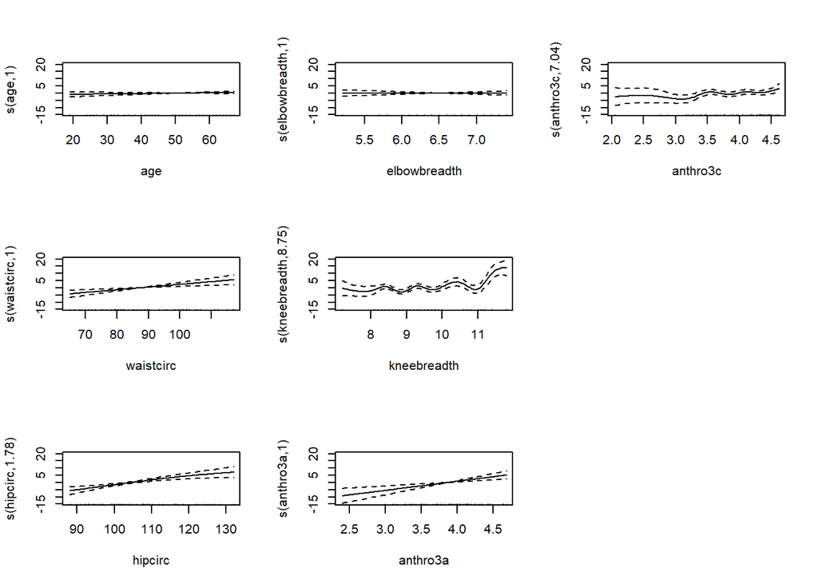

```r
layout(matrix(1:9, ncol = 3))
plot(bodyfat_gam)
```

Based on this plot, it looks like we don’t need to smooth all variables. Variables age, waistcirc, elbowbreadth & anthro3a appear linear and don’t need smoothing. To evaluate the covariate’s ‘informative’-ness, we should look at the p-values of the covariates.

```r
cat("Report model attributes")
```

```
## Report model attributes
```

```r
cat("GCV")
```

```
## GCV
```

```r
bodyfat_gam$gcv.ubre            # GCV
```

```
##   GCV.Cp
## 8.435412
```

```r
cat("AIC")
```

```
## AIC
```

```r
bodyfat_gam$aic                 # AIC
```

```
## [1] 345.708
```

```r
cat("Adjusted R-squared")
```

```
## Adjusted R-squared
```

```r
summary(bodyfat_gam)$r.sq       # Adjusted r-squared
```

```
## [1] 0.9528156
```

```r
cat("Total degrees of Freedom")
```

```
## Total degrees of Freedom
```

```r
sum(bodyfat_gam$edf)            # Total degrees of freedom
```

```
## [1] 22.57091
```

```r
cat("Some diagnostics for a fitted gam model using gam.check")
```

```
## Some diagnostics for a fitted gam model using gam.check
```

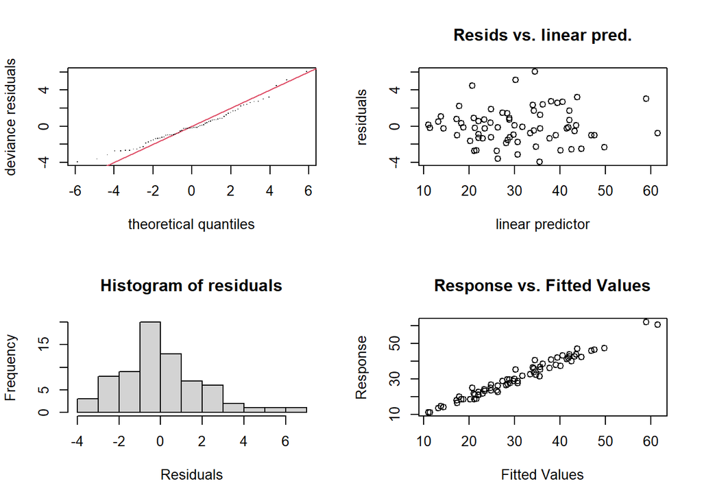

```
##
## Method: GCV   Optimizer: magic
## Smoothing parameter selection converged after 41 iterations.
## The RMS GCV score gradient at convergence was 2.767255e-07 .
## The Hessian was positive definite.
## Model rank =  64 / 64
##
## Basis dimension (k) checking results. Low p-value (k-index<1) may
## indicate that k is too low, especially if edf is close to k'.
##
##                   k'  edf k-index p-value
## s(age)          9.00 1.00    0.81   0.040 *
## s(waistcirc)    9.00 1.00    0.94   0.285
## s(hipcirc)      9.00 1.78    1.02   0.585
## s(elbowbreadth) 9.00 1.00    0.81   0.045 *
## s(kneebreadth)  9.00 8.75    1.08   0.690
## s(anthro3a)     9.00 1.00    1.09   0.700
## s(anthro3c)     9.00 7.04    0.89   0.150
## ---
## Signif. codes:  0 '***' 0.001 '**' 0.01 '*' 0.05 '.' 0.1 ' ' 1
```

```r
gam.check(bodyfat_gam)  # Response Vs Fitted values
```

```r
cat("Additionally we can also check for the train() method. Note that
train() won't allow for smoothing the variables; it evidently decides which to
smooth on its own.")
```

```
## Additionally we can also check for the train() method. Note that
## train() won't allow for smoothing the variables; it evidently decides which to
## smooth on its own.
```

```r
bf_train_gam <- train(DEXfat ~ age +  waistcirc + hipcirc + elbowbreadth +
                        kneebreadth + anthro3a + anthro3c,
                      data = bodyfat, method = "gam")
summary(bf_train_gam)
```

```
##
## Family: gaussian
## Link function: identity
##
## Formula:
## .outcome ~ s(elbowbreadth) + s(kneebreadth) + s(age) + s(hipcirc) +
##     s(waistcirc) + s(anthro3a) + s(anthro3c)
##
## Parametric coefficients:
##             Estimate Std. Error t value Pr(>|t|)
## (Intercept)  30.7828     0.2968   103.7   <2e-16 ***
## ---
## Signif. codes:  0 '***' 0.001 '**' 0.01 '*' 0.05 '.' 0.1 ' ' 1
##
## Approximate significance of smooth terms:
##                       edf Ref.df     F  p-value
## s(elbowbreadth) 3.186e-07      9 0.000   0.8024
## s(kneebreadth)  7.825e+00      9 6.978 5.34e-07 ***
## s(age)          6.695e-01      9 0.374   0.0271 *
## s(hipcirc)      1.843e+00      9 3.740  < 2e-16 ***
## s(waistcirc)    7.598e-01      9 2.512 6.01e-07 ***
## s(anthro3a)     6.742e-01      9 1.446 6.74e-06 ***
## s(anthro3c)     5.959e-01      9 0.975 4.74e-05 ***
## ---
## Signif. codes:  0 '***' 0.001 '**' 0.01 '*' 0.05 '.' 0.1 ' ' 1
##
## R-sq.(adj) =  0.949   Deviance explained = 95.8%
## GCV = 7.7062  Scale est. = 6.2553    n = 71
```

Here, not all covariates should be smoothed. Looking at the plot, the covariates that appear linear are: age, elbowbreadth, waistcirc and anthro3a. That leaves anthro3c, kneebreadth and hipcirc to be smoothed.

This summary shows that age, elbowbreadth, and anthro3c are not significant at the significance level of 0.05. The variables age, waistcirc, elbowbreadth and anthro3a all have linear relationships as shown in the plots. The model seems to give a moderate GCV and high AIC which could possibly be adjusted by variable selection and using smoothing functions on the variables mentioned above. The adjusted $R^2$ does indicate that the model explains most of the variance, but as stated previously, the model can improve.

Now we will remove the insignificant variables (`elbowbreadth` and `age`). We will also remove smoothing for some variables and report the summary, plot, GCV, AIC, adj-R$^2$.

```
bodyfat_gam2 <- gam(DEXfat~ waistcirc + s(hipcirc) +
                 s(kneebreadth)+ anthro3a +
                 s(anthro3c), data = bodyfat)
```

```r
# Removing insignificant elbowbreadth including age variables
bodyfat_gam2 <- gam(DEXfat ~ waistcirc + s(hipcirc) +
                      s(kneebreadth) + s(anthro3a) + s(anthro3c),
                    data = bodyfat)
# Assess Summary
summary(bodyfat_gam2)
```

```
##
## Family: gaussian
## Link function: identity
##
## Formula:
## DEXfat ~ waistcirc + s(hipcirc) + s(kneebreadth) + s(anthro3a) +
##     s(anthro3c)
##
## Parametric coefficients:
##             Estimate Std. Error t value Pr(>|t|)
## (Intercept) 13.60862    4.74887   2.866 0.006052 **
## waistcirc    0.19654    0.05425   3.623 0.000676 ***
## ---
## Signif. codes:  0 '***' 0.001 '**' 0.01 '*' 0.05 '.' 0.1 ' ' 1
##
## Approximate significance of smooth terms:
##                  edf Ref.df      F  p-value
## s(hipcirc)     1.610  2.010 10.910 0.000115 ***
## s(kneebreadth) 8.793  8.970  6.780 6.07e-06 ***
## s(anthro3a)    1.000  1.000 18.035 9.43e-05 ***
## s(anthro3c)    7.117  8.103  2.126 0.049342 *
## ---
## Signif. codes:  0 '***' 0.001 '**' 0.01 '*' 0.05 '.' 0.1 ' ' 1
##
## R-sq.(adj) =  0.954   Deviance explained = 96.7%
## GCV = 7.9464  Scale est. = 5.6498    n = 71
```

```r
# wastcirc and anthro3a are no longer the most signifcant parameter.

# Assess plot
cat("Plots for the model after removing insignificant variables")
```

```
## Plots for the model after removing insignificant variables
```

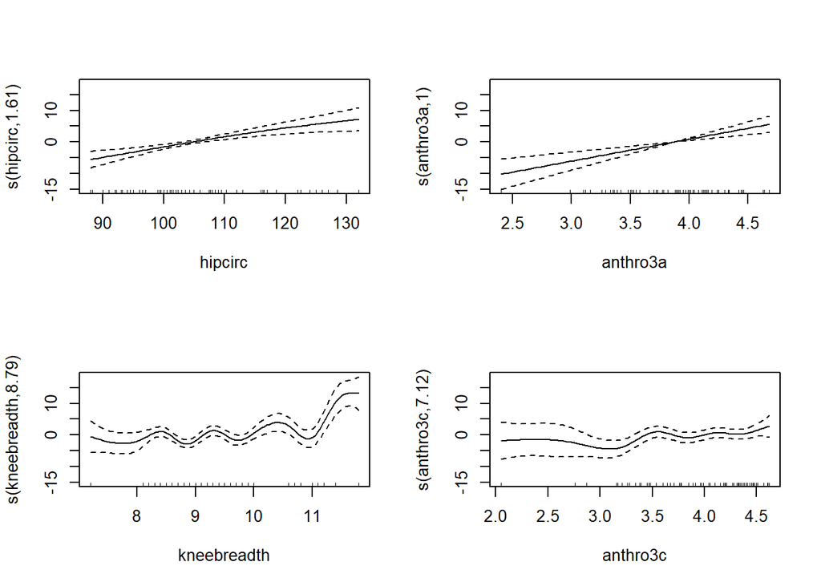

```r
layout(matrix(1:4, ncol = 2))
plot(bodyfat_gam2)
```

```r
# Report model attributes
cat("GCV of bodyfat_gam2")
```

```
## GCV of bodyfat_gam2
```

```r
bodyfat_gam2$gcv.ubre            # GCV
```

```
##   GCV.Cp
## 7.946447
```

```r
cat("AIC of bodyfat_gam2")
```

```
## AIC of bodyfat_gam2
```

```r
bodyfat_gam2$aic                 # AIC
```

```
## [1] 343.2562
```

```r
cat("Adjusted r-squared of bodyfat_gam2")
```

```
## Adjusted r-squared of bodyfat_gam2
```

```r
summary(bodyfat_gam2)$r.sq       # Adjusted r-squared
```

```
## [1] 0.9536683
```

```r
cat("Total Degrees of freedom of bodyfat_gam2")
```

```
## Total Degrees of freedom of bodyfat_gam2
```

```r
sum(bodyfat_gam2$edf)            # Total degrees of freedom
```

```
## [1] 20.52
```

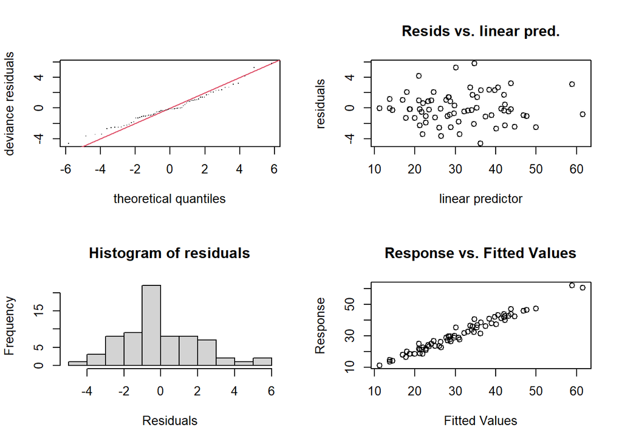

```
##
## Method: GCV   Optimizer: magic
## Smoothing parameter selection converged after 31 iterations.
## The RMS GCV score gradient at convergence was 7.054782e-07 .
## The Hessian was positive definite.
## Model rank =  38 / 38
##
## Basis dimension (k) checking results. Low p-value (k-index<1) may
## indicate that k is too low, especially if edf is close to k'.
##
##                  k'  edf k-index p-value
## s(hipcirc)     9.00 1.61    1.01    0.49
## s(kneebreadth) 9.00 8.79    1.06    0.66
## s(anthro3a)    9.00 1.00    1.11    0.76
## s(anthro3c)    9.00 7.12    0.91    0.21
```

```r
# run gam.check: is the normality assumption violated?
gam.check(bodyfat_gam2)
```

Based on the plot, it looks like we don’t need to smooth all variables. Variables `anthro3a` and “possibly” `hipcirc` appear linear.

GCV of bodyfat_gam2: 7.946447 AIC of bodyfat_gam2: 343.2562 Adjusted r-squared of bodyfat_gam2: 0.9536683 Total Degrees of freedom of bodyfat_gam2: 20.52

```r
log_transferred_DEX <- log(bodyfat$DEXfat)
df <- cbind (bodyfat, log_transferred_DEX)

bodyfat_gam3 <- gam(log_transferred_DEX ~ waistcirc + s(hipcirc) +
                      s(kneebreadth) + s(anthro3a) + s(anthro3c),
                    data = df)
# Assess Summary
summary(bodyfat_gam3)
```

```
##
## Family: gaussian
## Link function: identity
##
## Formula:
## log_transferred_DEX ~ waistcirc + s(hipcirc) + s(kneebreadth) +
##     s(anthro3a) + s(anthro3c)
##
## Parametric coefficients:
##             Estimate Std. Error t value Pr(>|t|)
## (Intercept) 2.973535   0.158102  18.808   <2e-16 ***
## waistcirc   0.004418   0.001806   2.447   0.0176 *
## ---
## Signif. codes:  0 '***' 0.001 '**' 0.01 '*' 0.05 '.' 0.1 ' ' 1
##
## Approximate significance of smooth terms:
##                  edf Ref.df      F  p-value
## s(hipcirc)     2.909  3.616 11.828  2.1e-06 ***
## s(kneebreadth) 2.325  2.962  2.027 0.128422
## s(anthro3a)    1.000  1.000 15.576 0.000227 ***
## s(anthro3c)    7.358  8.263  4.678 0.000180 ***
## ---
## Signif. codes:  0 '***' 0.001 '**' 0.01 '*' 0.05 '.' 0.1 ' ' 1
##
## R-sq.(adj) =  0.952   Deviance explained = 96.2%
## GCV = 0.0088137  Scale est. = 0.006878  n = 71
```

```r
# Assess plot
#layout(matrix(1:4, ncol = 2))
#plot(bodyfat_gam3)

# plot looks like we don't need to smooth all variables.  These appear linear:
# anthro3a.  Hipcirc is prominantly NOT linear in this light.


# Report model attributes
cat("GCV of bodyfat_gam3")
```

```
## GCV of bodyfat_gam3
```

```r
bodyfat_gam3$gcv.ubre            # GCV
```

```
##      GCV.Cp
## 0.008813659
```

```r
cat("AIC of bodyfat_gam3")
```

```
## AIC of bodyfat_gam3
```

```r
bodyfat_gam3$aic                 # AIC
```

```
## [1] -136.47
```

```r
cat("Adjusted R-square of bodyfat_gam3")
```

```
## Adjusted R-square of bodyfat_gam3
```

```r
summary(bodyfat_gam3)$r.sq       # Adjusted r-squared
```

```
## [1] 0.9522733
```

```r
cat("Total degrees of freedom of bodyfat_gam3")
```

```
## Total degrees of freedom of bodyfat_gam3
```

```r
sum(bodyfat_gam3$edf)            # Total degrees of freedom
```

```
## [1] 15.59274
```

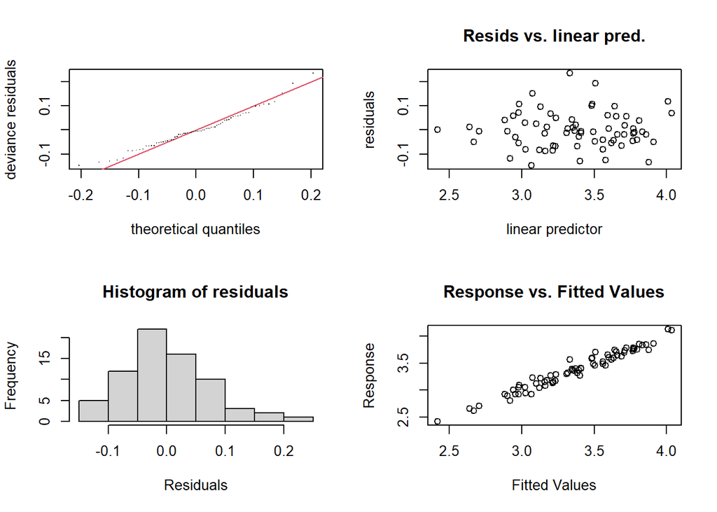

```
##
## Method: GCV   Optimizer: magic
## Smoothing parameter selection converged after 11 iterations.
## The RMS GCV score gradient at convergence was 5.573874e-08 .
## The Hessian was positive definite.
## Model rank =  38 / 38
##
## Basis dimension (k) checking results. Low p-value (k-index<1) may
## indicate that k is too low, especially if edf is close to k'.
##
##                  k'  edf k-index p-value
## s(hipcirc)     9.00 2.91    0.86   0.095 .
## s(kneebreadth) 9.00 2.33    0.83   0.075 .
## s(anthro3a)    9.00 1.00    1.00   0.425
## s(anthro3c)    9.00 7.36    0.99   0.420
## ---
## Signif. codes:  0 '***' 0.001 '**' 0.01 '*' 0.05 '.' 0.1 ' ' 1
```

```r
# run gam.check: is the normality assumption violated?
gam.check(bodyfat_gam3)
```

```r
cat("Plots for the model with log transferred response")
```

```
## Plots for the model with log transferred response
```

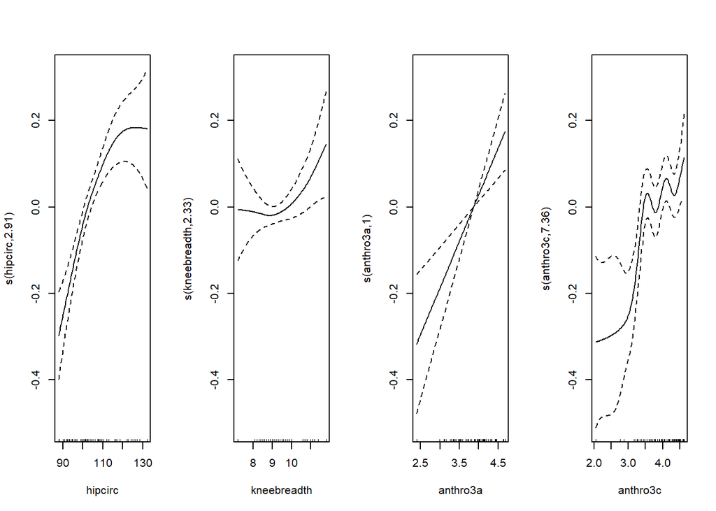

```r
par(mfrow=c(1,4))
plot(bodyfat_gam3)
```

Now, we fit a generalised additive model that underwent AIC-based variable selection (fitted using function $\textbf{gamboost()}$ function) and find out what variable is going removed by using AIC?

```
   bodyfat_boost <- gamboost(DEXfat~., data = bodyfat)
   bodyfat_aic <- AIC(bodyfat_boost)
   bf_gam <- bodyfat_boost[mstop(bodyfat_aic)]
```

```r
cat("# 1E")
```

```
## # 1E
```

```r
#

bodyfat_boost <- gamboost(DEXfat ~ ., data=bodyfat)
bodyfat_aic <- AIC(bodyfat_boost)
cat("printing AIC")
```

```
## printing AIC
```

```r
bodyfat_aic
```

```
## [1] 3.268173
## Optimal number of boosting iterations: 51
## Degrees of freedom (for mstop = 51): 7.637287
```

```r
bf_gam <- bodyfat_boost[mstop(bodyfat_aic)]

cat("plots for model fitted using gamboost:")
```

```
## plots for model fitted using gamboost:
```

```r
layout(matrix(1:9, ncol = 3))
plot(bf_gam)

cat("extract variable names")
```

```
## extract variable names
```

```r
extract(bf_gam,what='variable.names')
```

```
##    bbs(waistcirc, df = dfbase)      bbs(hipcirc, df = dfbase)
##                    "waistcirc"                      "hipcirc"
## bbs(elbowbreadth, df = dfbase)  bbs(kneebreadth, df = dfbase)
##                 "elbowbreadth"                  "kneebreadth"
##     bbs(anthro3a, df = dfbase)     bbs(anthro3b, df = dfbase)
##                     "anthro3a"                     "anthro3b"
##     bbs(anthro3c, df = dfbase)      bbs(anthro4, df = dfbase)
##                     "anthro3c"                      "anthro4"
```

```r
cat("Here, variable 'age' was removed")
```

```
## Here, variable 'age' was removed
```

[figure not shown]

Age variable was removed by gamboost() function.

Now, we will fit a logistic additive model to the glaucoma data. (Here we will use family = “binomial”). We will examine which covariates should enter the model and how their influence is on the probability of suffering from glaucoma. Since there are many covariates, we may want to use $\textbf{gamboost()}$ to fit the GAM model.

```r
library("TH.data")
data("GlaucomaM")
# cat("head(GlaucomaM)")
# head(GlaucomaM)
# nrow(GlaucomaM) # 196
# names(GlaucomaM)

glau_gamb <- gamboost(Class ~., data = GlaucomaM, family = Binomial())

summary(glau_gamb)
```

```
##
##   Model-based Boosting
##
## Call:
## gamboost(formula = Class ~ ., data = GlaucomaM, family = Binomial())
##
##
##   Negative Binomial Likelihood (logit link)
##
## Loss function: {
##      f <- pmin(abs(f), 36) * sign(f)
##      p <- exp(f)/(exp(f) + exp(-f))
##      y <- (y + 1)/2
##      -y * log(p) - (1 - y) * log(1 - p)
##  }
##
##
## Number of boosting iterations: mstop = 100
## Step size:  0.1
## Offset:  0
## Number of baselearners:  62
##
## Selection frequencies:
##  bbs(tmi, df = dfbase) bbs(mhcg, df = dfbase) bbs(vars, df = dfbase)
##                   0.17                   0.11                   0.11
## bbs(mhci, df = dfbase)  bbs(hvc, df = dfbase) bbs(vass, df = dfbase)
##                   0.10                   0.08                   0.08
##   bbs(as, df = dfbase) bbs(vari, df = dfbase)   bbs(mv, df = dfbase)
##                   0.07                   0.06                   0.04
## bbs(abrs, df = dfbase) bbs(mhcn, df = dfbase) bbs(phcn, df = dfbase)
##                   0.03                   0.03                   0.03
##  bbs(mdn, df = dfbase) bbs(phci, df = dfbase)  bbs(hic, df = dfbase)
##                   0.03                   0.02                   0.01
## bbs(phcg, df = dfbase)  bbs(mdi, df = dfbase)  bbs(tms, df = dfbase)
##                   0.01                   0.01                   0.01
```

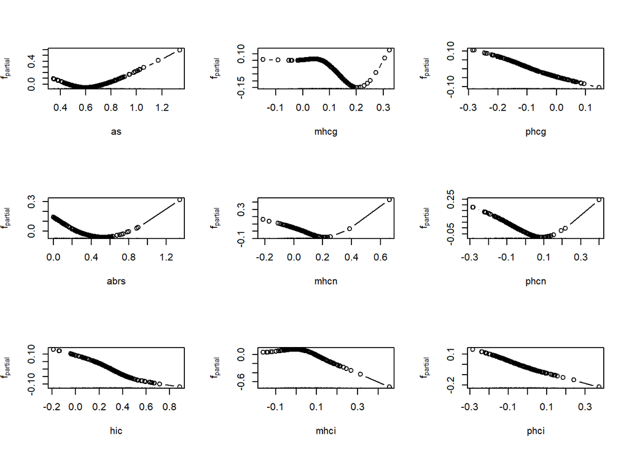

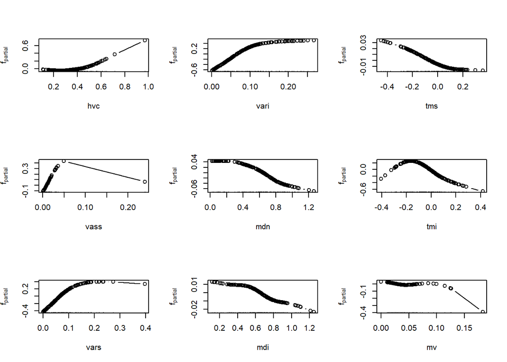

```r
layout(matrix(1:9, ncol = 3))
plot(glau_gamb)
```

```r
cat("Covariates that should enter the model as determined by gamboost:")
```

```
## Covariates that should enter the model as determined by gamboost:
```

```r
# extract(glau_gamb,what='variable.names')
var_names  <- unname(extract(glau_gamb,what='variable.names'))
var_names
```

```
##  [1] "as"   "abrs" "hic"  "mhcg" "mhcn" "mhci" "phcg" "phcn" "phci" "hvc"
## [11] "vass" "vars" "vari" "mdn"  "mdi"  "tms"  "tmi"  "mv"
```

```r
#Using the variables indicated by gamboost, run a gam model to get summary data
# phcg and phci seem smooth already
glau_gam <- gam(Class ~ s(as) + s(abrs)   + s(hic)  + s(mhcg)  + s(mhcn) + s(mhci)             +   phcg +  s(phcn)  + phci + s(hvc) + s(vass) + s(vars) + s(vari) +                   s(mdn) + s(mdi) + s(tms) +  s(tmi) + s(mv),
                data=GlaucomaM, family=binomial)

summary(glau_gam)
```

```
##
## Family: binomial
## Link function: logit
##
## Formula:
## Class ~ s(as) + s(abrs) + s(hic) + s(mhcg) + s(mhcn) + s(mhci) +
##     phcg + s(phcn) + phci + s(hvc) + s(vass) + s(vars) + s(vari) +
##     s(mdn) + s(mdi) + s(tms) + s(tmi) + s(mv)
##
## Parametric coefficients:
##             Estimate Std. Error z value Pr(>|z|)
## (Intercept)    15.56    1663.62   0.009    0.993
## phcg          602.62   11945.23   0.050    0.960
## phci         -295.56   11035.50  -0.027    0.979
##
## Approximate significance of smooth terms:
##           edf Ref.df Chi.sq p-value
## s(as)   1.395  1.433  0.006   0.996
## s(abrs) 1.000  1.000  0.001   0.971
## s(hic)  1.000  1.000  0.002   0.966
## s(mhcg) 1.000  1.000  0.001   0.976
## s(mhcn) 1.330  1.360  0.000   0.999
## s(mhci) 2.745  2.826  0.002   1.000
## s(phcn) 4.022  4.101  0.003   1.000
## s(hvc)  5.394  5.602  0.015   1.000
## s(vass) 1.000  1.000  0.015   0.904
## s(vars) 1.000  1.000  0.001   0.970
## s(vari) 3.600  3.691  0.010   1.000
## s(mdn)  1.000  1.000  0.000   0.989
## s(mdi)  1.000  1.000  0.001   0.972
## s(tms)  1.000  1.000  0.000   0.999
## s(tmi)  2.467  2.535  0.010   0.999
## s(mv)   1.000  1.000  0.006   0.938
##
## R-sq.(adj) =      1   Deviance explained =  100%
## UBRE = -0.66687  Scale est. = 1         n = 196
```

Next, we will investigate the use of different types of scatterplot smoothers on the $Hubble$ dataset.

```r
## GAM model
library("HSAUR3")
library("mgcv")
library("GGally")
library("mboost")
library("rpart")
library("wordcloud")

data("hubble", package = "gamair")
head(hubble)
```

```
##     Galaxy    y     x
## 1  NGC0300  133  2.00
## 2  NGC0925  664  9.16
## 3 NGC1326A 1794 16.14
## 4  NGC1365 1594 17.95
## 5  NGC1425 1473 21.88
## 6  NGC2403  278  3.22
```

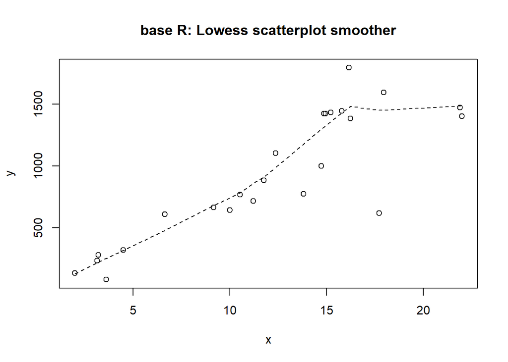

```r
sorted_value<-hubble[order(hubble$x),]
x <- sorted_value$x
y <- sorted_value$y

lowess_value <- lowess(x, y)
plot(y~x, data = sorted_value, xlab = "x", ylab = "y",main="base R: Lowess scatterplot smoother")
lines(lowess_value, lty = 2)
```

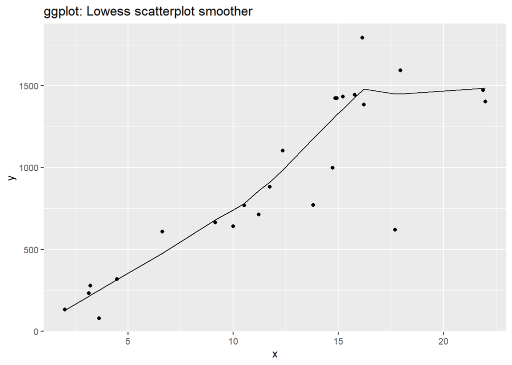

```r
ggplot() + aes(x=x, y=y) +
  geom_point()+
  geom_line(aes(x = lowess_value$x, y = lowess_value$y)) +
    labs(title = "ggplot: Lowess scatterplot smoother")
```

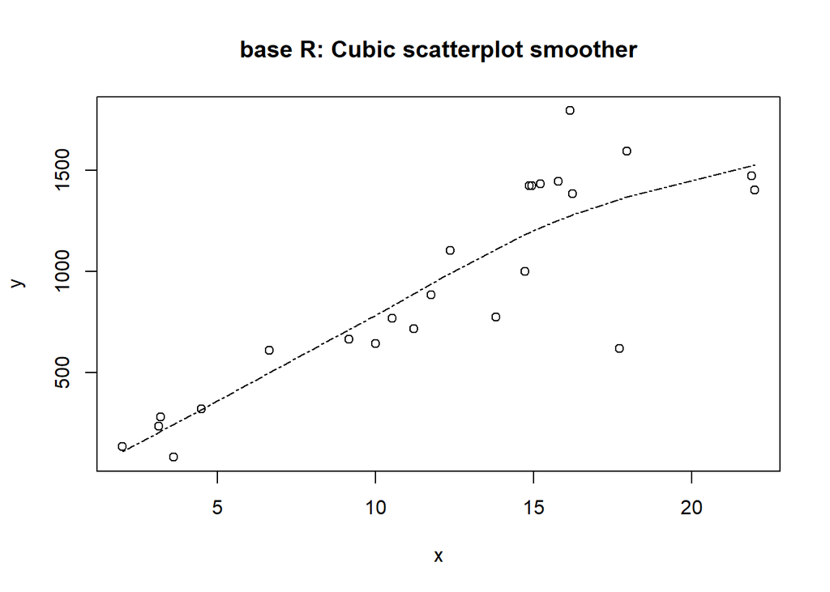

```r
plot(y~x, data = sorted_value, xlab = "x", ylab = "y",main="base R: Cubic scatterplot smoother")
cubic_value = gam(y ~ s(x, bs = "cr"), data = sorted_value)
lines(sorted_value$x, predict(cubic_value), lty=6)
```

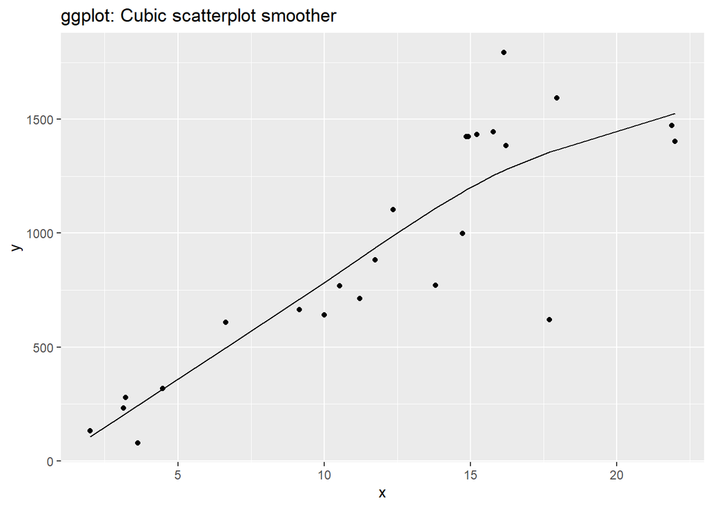

```r
ggplot() + aes(x=x, y=y) +
  geom_point()+
  geom_line(aes(x = sorted_value$x, y = predict(cubic_value))) +
    labs(title = "ggplot: Cubic scatterplot smoother")
```

```r
summary(cubic_value)
```

```
##
## Family: gaussian
## Link function: identity
##
## Formula:
## y ~ s(x, bs = "cr")
##
## Parametric coefficients:
##             Estimate Std. Error t value Pr(>|t|)
## (Intercept)   924.38      51.87   17.82 4.27e-14 ***
## ---
## Signif. codes:  0 '***' 0.001 '**' 0.01 '*' 0.05 '.' 0.1 ' ' 1
##
## Approximate significance of smooth terms:
##        edf Ref.df    F  p-value
## s(x) 2.148  2.648 26.8 2.35e-07 ***
## ---
## Signif. codes:  0 '***' 0.001 '**' 0.01 '*' 0.05 '.' 0.1 ' ' 1
##
## R-sq.(adj) =  0.754   Deviance explained = 77.7%
## GCV =  74317  Scale est. = 64570     n = 24
```

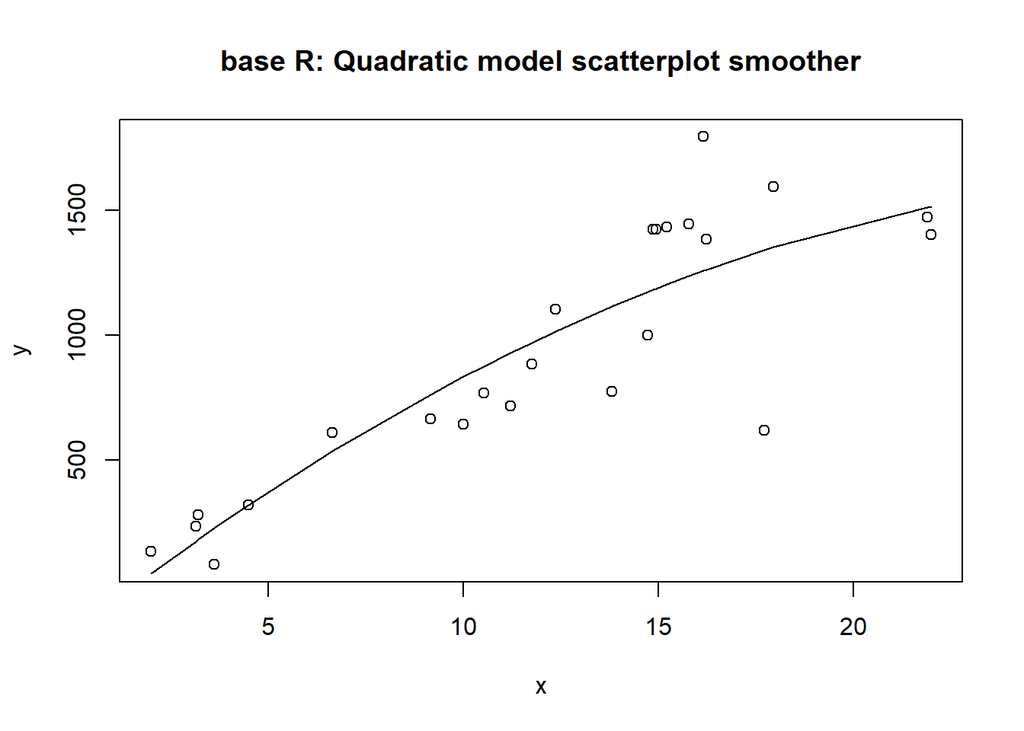

```r
plot(y~x, data = sorted_value, xlab = "x", ylab = "y",main="base R: Quadratic model scatterplot smoother")
lm_value = lm(y~x+I(x^2), data = sorted_value)
lines(sorted_value$x, predict(lm_value))
```

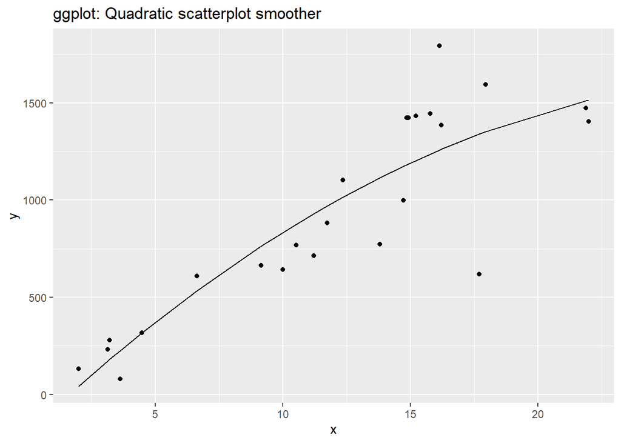

```r
ggplot() + aes(x=x, y=y) +
  geom_point()+
  geom_line(aes(x = sorted_value$x, y = predict(lm_value))) +
    labs(title = "ggplot: Quadratic scatterplot smoother")
```